# B11_BT_luong_cuc_dai

[figure not shown]

### **1. Phát biểu bài toán**

### **2. Lát cắt**

### **3. Đồ thị tăng luồng và đường tăng luồng**

### **4. Thuật toán Ford-Fulkerson**

### **5. Một số bài toán luồng tổng quát và ứng dụng**

# 1. Phát biểu bài toán

## 1.1. Mạng

**Định nghĩa:** Mạng là đơn đồ thị có hướng $G=(V,E)$ thỏa mãn:

Có duy nhất một đỉnh $s$ không có cung đi vào (gọi là *đỉnh phát* hay *nguồn*) và duy nhất một đỉnh $t$ không có cung đi ra (gọi là *đỉnh thu* hay *đích*)

Mỗi cung $e\in E$ được gắn với một số không âm $c(e)$ được gọi là *khả năng thông qua* của $e$.

[figure not shown]

## 1.2. Luồng

**Định nghĩa:** Luồng $f:E\to\mathbb R^+$ trong mạng $G=(V,E)$ thỏa mãn:

Hạn chế khả năng thông qua: $0\leq f(e)\leq c(e)$ với $e\in E$.

Điều kiện cân bằng luồng: với $v\neq s,\, t$ thì $\sum\limits_{e\in E^-(v)}f(e)=\sum\limits_{e\in E^+(v)}f(e)$ (trong đó, $E^-(v)$ tập các cung đi vào $v$; $E^+(v)$ tập các cung đi ra khỏi $v$).

**Định nghĩa:** Giá trị của luồng $f$ $$\text{val }f=\sum\limits_{e\in E^+(s)}f(e)=\sum\limits_{e\in E^-(t)}f(e)$$

## 1.3. Bài toán luồng cực đại

Luồng trong mạng $G=(V,E)$ được gọi là **luồng cực đại** nếu trong số tất cả các luồng trong mạng $G$ nó là luồng có giá trị lớn nhất

Bài toán tìm luồng cực đại trong mạng $G=(V,E)$ được gọi là **bái toán luồng cực đại**.

# **2. Lát cắt**

## 2.1. Lát cắt

**Định nghĩa:**

- **Lát cắt:** là cách phân hoạch tập đỉnh của đồ thị thành 2 tập $S$ và $T$ sao cho $s\in S$ và $t\in T$.
- **Khả năng thông qua:** $$\text{cap}(S,T)=\sum\limits_{e\in S\to T} c(e)\text{ trong đó }S\to T=\{(v,w)\in E:\,v\in S,\, w\in T\}.$$
- **Lát cắt nhỏ nhất (hẹp nhất):** là lát cắt với khả năng thông qua nhỏ nhất.

|  | $S=\{s\}$, $T=V\setminus S$ $\text{cap}(S,T)=10+5+15=30$ |
| --- | --- |

| $S=\{s,a,b,c\}$, $T=V\setminus S$ $\text{cap}(S,T)=9+15+8+30=62$ | $S=\{s,b,c,z\}$, $T=V\setminus S$ $\text{cap}(S,T)=10+8+10=28$ |
| --- | --- |

## 2.2. Luồng chảy qua lát cắt

**Định nghĩa:** Giả sử $f$ là luồng trong mạng và lát cắt $(S,T)$. Giá trị luồng chảy qua lát cắt $(S,T)$ là đại lượng $$\sum\limits_{e\in S\to T} f(e)-\sum\limits_{e\in T\to S} f(e)$$

| $S=\{s\}$, $T=V\setminus S$ Luồng chảy qua $(S,T)=(10+4+10)-0=24$ | $S=\{s,a,b,c\}$, $T=V\setminus S$ Luồng chảy qua $(S,T)=(6+0+8+10)-0=24$ |
| --- | --- |

[figure not shown]

$S=\{s,b,c,z\}$, $T=V\setminus S$

Luồng chảy qua $(S,T)=(10+8+10)-(0+4)=24$

**Định lý:** Giả sử $f$ là luồng và $(S,T)$ là lát cắt. Khi đó

$\sum\limits_{e\in S\to T} f(e)-\sum\limits_{e\in T\to S} f(e)=\sum\limits_{e\in E^+(s)}f(e)=\sum\limits_{e\in E^-(t)}f(e)=\text{val }f$

$\text{val }f\leq \text{cap }(S,T)=\sum\limits_{e\in S\to T}c(e)$

Nếu $\text{val }f=\text{cap }(S,T)$ thì $f$ là luồng cực đại và $(S,T)$ là lát cắt hẹp nhất.

# **3. Đồ thị tăng luồng và đường tăng luồng**

## 3.1. Thuật toán tham lam

[figure not shown]

- Bắt đầu từ luồng có giá trị $0$
- Tìm đường đi $P$ từ $s$ đến $t$ trong đó mỗi $e\in E$ thỏa mãn $f(e)\leq c(e)$
- Tăng luồng dọc theo đường đi $P$
- Lặp lại cho đến khi gặp bế tắc

[figure not shown]

| $s\to a\to y\to t$ | $s\to b\to x\to t$ |
| --- | --- |

| Giá trị luồng: $10$ | Giá trị luồng: $14$ |
| --- | --- |

## 3.2. Đồ thị tăng luồng

| Mạng đã cho $G=(V,E)$ - Cung $e=(v,w)\in E$ - Luồng $f(e)=6$ - Khả năng thông qua $c(e)=17$ | Đồ thị tăng luồng $G_f=(V,E_f)$ - $E_f=\{e:f(e)< c(e)\}\cup \{e^R:f(e)>0\}$ - $c_f(e)=\begin{cases}c(e)-f(e)&\text{nếu }e\in E\\f(e)&\text{nếu }e^R\in E\end{cases}$ |
| --- | --- |

## 3.3. Đường tăng luồng

**Định nghĩa:**  
- Đường tăng luồng là đường đi từ $s$ đến $t$ trên đồ thị tăng luồng.  
- Khả năng thông qua của đường đi $P$ là $c_f(P)=\min\{c_f(e): e\in P\}$.

**Ví dụ:** Xét đường tăng luồng $P: s\to a\to y\to b\to x\to t$

[figure not shown]

có $c_f(P)=4$.

| Giá trị luồng: $14$ |  |
| --- | --- |

**Định lí (Ford-Fulkerson 1956):**

Luồng là cực đại khi và chỉ khi không tìm được đường tăng luồng.

Giá trị của luồng cực đại bằng khả năng thông qua của lát cắt nhỏ nhất.

# **4. Thuật toán Ford-Fulkerson**

### Xây dựng luồng cực đại cho đồ thị sau:

[figure not shown]

| Giá trị luồng: $0$ | Đường tăng luồng $P: s\to a\to y\to t$ $c_f(P)=4$ |
| --- | --- |

| Giá trị luồng: $4$ | Đường tăng luồng $P: s\to b\to x\to t$ $c_f(P)=4$ |
| --- | --- |

| Giá trị luồng: $8$ | Đường tăng luồng $P: s\to b\to y\to t$ $c_f(P)=6$ |
| --- | --- |

| Giá trị luồng: $14$ | Không tồn tại đường tăng luồng |
| --- | --- |

**Thuật toán:**

- **for** $e \in E$: // `Khởi tạo luồng 0`
  - $f(e)\leftarrow 0$
- $G_f \leftarrow$ `đồ thị tăng luồng`
- **while** `tìm được đường tăng luồng P trên` $G_f$
  - $f\leftarrow$ `augment`$(f,P)$
  - `Cập nhật`$G_f$
- **return** $f$
- **augment(f,P)**
  - $b\leftarrow c_f(P)$
  - **for** $e\in P$
    - **if** $e\in E$ `thì` $f(e):=f(e)+b$ //`cạnh thuận`
    - **else** `thì` $f(e^R):=f(e)-b$ // `cạnh nghịch`
  - **return** $f$

### Xây dựng luồng cực đại cho đồ thị sau:

[figure not shown]

| Giá trị luồng: $0$ | Đường tăng luồng $P: s\to a\to b\to y\to x\to t$ $c_f(P)=2$ |
| --- | --- |

| Giá trị luồng: $2$ | Đường tăng luồng $P: s\to a\to x\to t$ $c_f(P)=4$ |
| --- | --- |

| Giá trị luồng: $6$ | Đường tăng luồng $P: s\to a\to y\to x\to t$ $c_f(P)=4$ |
| --- | --- |

| Giá trị luồng: $10$ | Đường tăng luồng $P: s\to b\to a\to y\to t$ $c_f(P)=2$ |
| --- | --- |

| Giá trị luồng: $12$ | Đường tăng luồng $P: s\to b\to y\to t$ $c_f(P)=7$ |
| --- | --- |

| Giá trị luồng: $19$ | Không tồn tại đường tăng luồng |
| --- | --- |

**Chú ý:**

- Nếu khả năng thông qua lớn nhất là $C$ thì thuật toán có thể phải thực hiện $C$ bước lặp
- Thuật toán có thể không dừng nếu khả năng thông qua là số vô tỉ
- Việc lựa chọn đường tăng luồng có thể dẫn đến độ phức tạp của thuật toán là hàm mũ.
- Edmond-Karp đề xuất cách chọn đường tăng luồng hiệu quả là đường có số cạnh ít nhất (sử dụng BFS).

### Sử dụng BFS và kỹ thuật ghi nhãn để xây dựng luồng cực đại cho đồ thị sau:

[figure not shown]

| Giá trị luồng: $0$ | Đường tăng luồng $P: s\to a\to x\to t$ $c_f(P)=4$ |
| --- | --- |

| Giá trị luồng: $4$ | Đường tăng luồng $P: s\to a\to y\to t$ $c_f(P)=6$ |
| --- | --- |

| Giá trị luồng: $10$ | Đường tăng luồng $P: s\to b\to y\to t$ $c_f(P)=4$ |
| --- | --- |

| Giá trị luồng: $14$ | Đường tăng luồng $P: s\to b\to y\to x\to t$ $c_f(P)=5$ |
| --- | --- |

| Giá trị luồng: $19$ | Không còn đường tăng luồng |
| --- | --- |

# **5. Một số bài toán luồng tổng quát và ứng dụng**

## **5.1 Một số bài toán luồng tổng quát**

### **a) Bài toán mạng với nhiều điểm phát và điểm thu**

### **b) Bài toán mạng với khả năng thông qua của các cung và các đỉnh**

## **5.2 Một số ứng dụng**

### **a) Bài toán đám cưới vùng quê**

### **b) Bài toán phân nhóm sinh hoạt**

### **c) Bài toán lập lịch phân phòng họp cho hội nghị**

[figure not shown]

```python
# chọn đường tăng luông theo thứ tự từ điển trong graph, lưu ý cung nghịch sẽ đc tạo ngay sau thứ tự của đỉnh đang xét
def ford_fulkerson(graph, source, sink):
    flow = {}
    for u in graph:
        for v in graph[u]:
            flow[(u, v)] = 0     # Khởi tạo luồng: f(u,v) = 0 với mọi cạnh u→v trong graph

    def build_residual_graph():
        residual = {}
        for u in graph:
            for v in graph[u]:
                cap = graph[u][v]
                f = flow.get((u, v), 0)
                if cap - f > 0:
                    if u not in residual:
                        residual[u] = {}
                    residual[u][v] = cap - f
                if f > 0:
                    if v not in residual:
                        residual[v] = {}
                    residual[v][u] = f  # cạnh nghịch
        return residual

    def find_path(u, visited, path, residual):
        if u == sink:
            return path
        visited.add(u)
        if u in residual:
            for v in residual[u]:  # đúng thứ tự trong graph
                if v not in visited and residual[u][v] > 0:
                    result = find_path(v, visited, path + [(u, v)], residual)
                    if result:
                        return result
        return None

    def augment(path, residual):
        bottleneck = min(residual[u][v] for u, v in path)
        for u, v in path:
            if (u, v) in flow:
                flow[(u, v)] += bottleneck  # cạnh thuận
            else:
                flow[(v, u)] -= bottleneck  # cạnh nghịch
        return bottleneck

    def print_residual_graph(residual):
        print("Đồ thị tăng luồng Gf:")
        for u in residual:
            for v in residual[u]:
                print(f"  {u} → {v}: {residual[u][v]}")
        print("-" * 40)

    max_flow = 0
    iteration = 1
    while True:
        residual = build_residual_graph()
        print(f"\n🌀 Bước lặp {iteration}")
        print_residual_graph(residual)
        visited = set()
        path = find_path(source, visited, [], residual)
        if not path:
            print("Không còn đường tăng. Kết thúc.")
            break
        print("🔗 Đường tăng luồng:", ' → '.join(u for u, v in path) + f" → {sink}")
        bottleneck = augment(path, residual)
        print(f"🧊 c_f(P) = {bottleneck}")
        print("🔁 Cập nhật luồng:")
        for u, v in path:
            if (u, v) in flow:
                print(f"  {u} → {v}: {flow[(u, v)]}")
            else:
                print(f"  {v} → {u}: {flow[(v, u)]}")
        max_flow += bottleneck
        iteration += 1

    print("\n✅ Kết thúc. Max flow:", max_flow)
    print("Luồng cuối cùng:")
    for (u, v) in flow:
        if flow[(u, v)] > 0:
            print(f"  {u} → {v}: {flow[(u, v)]}")
    return max_flow, flow

# Đồ thị ví dụ
graph = {
    's': {'a': 10, 'b': 10},
    'a': {'b': 2, 'x': 4, 'y': 8},
    'b': {'y': 9},
    'x': {'t': 10},
    'y': {'x': 6,'t': 10},
    't': {}
}

ford_fulkerson(graph, 's', 't')
```

```
🌀 Bước lặp 1
Đồ thị tăng luồng Gf:
  s → a: 10
  s → b: 10
  a → b: 2
  a → x: 4
  a → y: 8
  b → y: 9
  x → t: 10
  y → x: 6
  y → t: 10
----------------------------------------
🔗 Đường tăng luồng: s → a → b → y → x → t
🧊 c_f(P) = 2
🔁 Cập nhật luồng:
  s → a: 2
  a → b: 2
  b → y: 2
  y → x: 2
  x → t: 2

🌀 Bước lặp 2
Đồ thị tăng luồng Gf:
  s → a: 8
  s → b: 10
  a → s: 2
  a → x: 4
  a → y: 8
  b → a: 2
  b → y: 7
  y → b: 2
  y → x: 4
  y → t: 10
  x → t: 8
  x → y: 2
  t → x: 2
----------------------------------------
🔗 Đường tăng luồng: s → a → x → t
🧊 c_f(P) = 4
🔁 Cập nhật luồng:
```

[output cut: 85 more lines]

```
  t → x: 10
  t → y: 9
----------------------------------------
Không còn đường tăng. Kết thúc.

✅ Kết thúc. Max flow: 19
Luồng cuối cùng:
  s → a: 10
  s → b: 9
  a → x: 4
  a → y: 6
  b → y: 9
  x → t: 10
  y → x: 6
  y → t: 9
```

```
(19,
 {('s', 'a'): 10,
  ('s', 'b'): 9,
  ('a', 'b'): 0,
  ('a', 'x'): 4,
  ('a', 'y'): 6,
  ('b', 'y'): 9,
  ('x', 't'): 10,
  ('y', 'x'): 6,
  ('y', 't'): 9})
```

```python
#code ưu tiên đường tăng luồng có khả năng thông qua c_f lớn nhất
def ford_fulkerson(graph, source, sink):
    # Khởi tạo luồng ban đầu
    flow = {}
    nodes = set(graph.keys())
    for u in graph:
        for v in graph[u]:
            flow[(u, v)] = 0
            # Nếu chưa có cạnh ngược thì thêm vào
            if (v, u) not in flow:
                flow[(v, u)] = 0
            nodes.add(v)

    # Hàm xây dựng đồ thị dư
    def build_residual_graph():
        Gf = {u: {} for u in nodes}
        for (u, v), f in flow.items():
            capacity = graph[u][v] if (u in graph and v in graph[u]) else 0
            residual = capacity - f
            if residual > 0:
                Gf[u][v] = residual
            if f > 0:
                Gf[v][u] = f
        return Gf

    # Hàm tìm đường tăng luồng theo thứ tự từ điển, ưu tiên bottleneck lớn nhất
    def find_augmenting_path(Gf, s, t):
        visited = set()
        path = []

        def dfs(u):
            if u == t:
                return True
            visited.add(u)
            # Sắp xếp theo dung lượng giảm dần, sau đó theo thứ tự từ điển
            for v in sorted(Gf[u], key=lambda k: (-Gf[u][k], k)):
                if v not in visited and Gf[u][v] > 0:
                    path.append((u, v))
                    if dfs(v):
                        return True
                    path.pop()
            return False

        if dfs(s):
            return path
        else:
            return None

    max_flow = 0
    step = 1
    while True:
        Gf = build_residual_graph()
        print(f"\n=== BƯỚC {step} ===")
        print("Đồ thị tăng luồng G_f:")
        for u in sorted(Gf):
            for v in sorted(Gf[u]):
                print(f"  {u} → {v}: {Gf[u][v]}")
        P = find_augmenting_path(Gf, source, sink)
        if not P:
            print("🚫 Không còn đường tăng.")
            break
        bottleneck = min(Gf[u][v] for u, v in P)
        print(f"✔️ Đường tăng luồng tìm được: {' → '.join([u for u, v in P] + [sink])}")
        print(f"🔧 c_f(P): {bottleneck}")
        for u, v in P:
            if (u, v) in flow:
                flow[(u, v)] += bottleneck
            else:
                flow[(v, u)] -= bottleneck
        max_flow += bottleneck
        step += 1

    print(f"\n✅ Tổng luồng cực đại: {max_flow}")
    print("🔄 Luồng qua các cạnh:")
    for (u, v), f in flow.items():
        if f > 0 and (u in graph and v in graph[u]):
            print(f"  {u} → {v}: {f}")
    return max_flow

# Đồ thị ví dụ
graph = {
    's': {'a': 10, 'b': 10},
    'a': {'b': 2, 'x': 4, 'y': 8},
    'b': {'y': 9},
    'x': {'t': 10},
    'y': {'x': 6, 't': 10},
    't': {}
}

ford_fulkerson(graph, 's', 't')
```

[output not shown]

[output cut: 42 more lines]

[output not shown]

```
19
```

```python
#code thuật toán sử dụng tìm đường đi bằng BFS
from collections import deque

def bfs(residual_graph, source, sink, parent):
    visited = set()
    queue = deque([source])
    visited.add(source)
    parent.clear()

    while queue:
        u = queue.popleft()
        for v in residual_graph.get(u, {}):
            if v not in visited and residual_graph[u][v] > 0:
                parent[v] = u
                if v == sink:
                    return True
                visited.add(v)
                queue.append(v)
    return False

def ford_fulkerson(graph, source, sink):
    # Khởi tạo đồ thị dư
    residual_graph = {}
    for u in graph:
        if u not in residual_graph:
            residual_graph[u] = {}
        for v in graph[u]:
            # thêm cạnh thuận
            residual_graph[u][v] = graph[u][v]
            # thêm đỉnh đích nếu chưa có
            if v not in residual_graph:
                residual_graph[v] = {}
            # thêm cạnh nghịch với trọng số 0 nếu chưa có
            if u not in residual_graph[v]:
                residual_graph[v][u] = 0

    parent = {}
    max_flow = 0

    while bfs(residual_graph, source, sink, parent):
        path_flow = float('inf')
        s = sink
        while s != source:
            path_flow = min(path_flow, residual_graph[parent[s]][s])
            s = parent[s]

        # Cập nhật đồ thị dư
        v = sink
        while v != source:
            u = parent[v]
            residual_graph[u][v] -= path_flow
            residual_graph[v][u] += path_flow
            v = parent[v]

        max_flow += path_flow

        # In đường tăng
        path = []
        node = sink
        while node != source:
            path.append(node)
            node = parent[node]
        path.append(source)
        path.reverse()
        print(f"Đường tăng: {' -> '.join(path)}, tăng luồng: {path_flow}")

    return max_flow

graph = {
    's': {'a': 10, 'b': 10},
    'a': {'b': 2, 'x': 4, 'y': 8},
    'b': {'y': 9},
    'x': {'t': 10},
    'y': {'x': 6, 't': 10},
    't': {}
}

maxflow = ford_fulkerson(graph, 's', 't')
print("Max flow:", maxflow)
```

```
Đường tăng: s -> a -> x -> t, tăng luồng: 4
Đường tăng: s -> a -> y -> t, tăng luồng: 6
Đường tăng: s -> b -> y -> t, tăng luồng: 4
Đường tăng: s -> b -> y -> x -> t, tăng luồng: 5
Max flow: 19
```

[figure not shown]

```python
import matplotlib.pyplot as plt
import networkx as nx
from matplotlib.patches import Rectangle

edges = [
    ("(s,+INF)", "b(s+,1)")
]

G = nx.DiGraph()
G.add_edges_from(edges)
pos = {
    "(s,+INF)": (0.5, 0),

    "b(s+,1)": (1, 0)
}

plt.figure(figsize=(4, 3))

# Vẽ chỉ cạnh và label, không vẽ node hình tròn
nx.draw_networkx_edges(G, pos)
nx.draw_networkx_labels(G, pos, font_size=12)

# Vẽ node hình chữ nhật
ax = plt.gca()
for node, (x, y) in pos.items():
    label = node
    char_width = 0.03
    width = char_width * len(label) + 0.05
    height = 0.002
    rect = Rectangle((x - width / 2, y - height / 2), width, height,
                     facecolor='lightgreen', edgecolor='black')
    ax.add_patch(rect)

plt.axis('off')
plt.title("Đường tăng luồng")
plt.show()
```

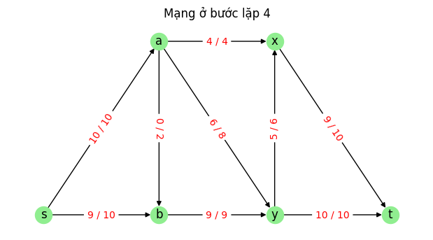

```python
import matplotlib.pyplot as plt
import networkx as nx

# Tạo đồ thị vô hướng
G = nx.DiGraph()

# Danh sách các cạnh
edges = [("s", "a"),("s", "b"),("a", "y"),("y", "x"),("b", "y"),("x", "t"),("y", "t"),("a", "x"),("a", "b")]
#edges = [("b", "y")("s", "a"),]
pos = {"s": (0, 0), "a": (0.5, 0.25), "b": (0.5, 0),"y": (1, 0), "t": (1.5, 0),"x": (1, 0.25)}
#edges = [("v", "w")]
#pos = {"v": (0, 0),"w": (0.5, 0)}
# Thêm các cạnh vào đồ thị
G.add_edges_from(edges)
#G.add_nodes_from(["x","a","s","t","y"])
# Vẽ đồ thị
plt.figure(figsize=(6, 3))

# Vẽ graph
nx.draw(G, pos, with_labels=True, node_color="lightgreen", node_size=300, font_size=12)
#nx.draw_networkx_edges(G, pos, edgelist=[("s", "b"),("b", "y"),("y", "t")], edge_color='teal', width=1)
#nx.draw_networkx_edges(G, pos, edgelist=[("y", "z"),("a", "b")], edge_color='blue', width=2)
# Thêm nhãn cho các cạnh
#edge_labels = {("a", "s"):"10",("s", "b"):"1",("b", "a"):"2",("a", "y"):"2",("a", "x"):"4",("y", "b"):"9",("y", "x"):"6",("x", "t"):"10",("y", "t"):"1"}
edge_labels = {("s", "a"):"10 / 10",("s", "b"):"9 / 10",("a", "y"):"6 / 8",("y", "x"):"5 / 6",("b", "y"):"9 / 9",("x", "t"):"9 / 10",("y", "t"):"10 / 10",("a", "x"):"4 / 4",("a", "b"):"0 / 2"}
#edge_labels = {("v", "w"):"11"}

# nx.draw_networkx_edges(G, pos, connectionstyle="arc3,rad=-0.3", arrowsize=25, edge_color="red", edgelist=[("b", "s", 2),("t", "y", 2),("y", "a", 2)])
# edge_labels1 = {("b", "s"):"9",("t", "y"):"9",("y", "a"):"6"}
# nx.draw_networkx_edge_labels(G, pos, edge_labels=edge_labels1, connectionstyle="arc3,rad=-0.3", font_color="red", font_size=10)
# nx.draw_networkx_edges(G, pos, connectionstyle="arc3,rad=0.3", arrowsize=25, edge_color="red", edgelist=[("a", "s", 2),("t", "x",2)])
# edge_labels2 = {("a", "s"):"6",("t", "x"):"6"}
# nx.draw_networkx_edge_labels(G, pos, edge_labels=edge_labels2, connectionstyle="arc3,rad=0.3", font_color="red", font_size=10)
# nx.draw_networkx_edges(G, pos, edgelist=[("a", "s"),("x", "a"),("t", "x"),("x", "y"),("y", "b")], edge_color='red')
# nx.draw_networkx_edges(G, pos, edgelist=[("s", "b"),("y", "t"),("a", "y")], edge_color='blue')
nx.draw_networkx_edge_labels(G, pos, edge_labels=edge_labels, font_color="red", font_size=10)
plt.title("Mạng ở bước lặp 4")
plt.show()
```